# Assignment 6

Grant Lam

December 8, 2015

ID: 998319337  
Discussion TA: Michael

I did this assignment by myself and developed and wrote the code for each part by myself, drawing only from class, section, Piazza posts and the Web. I did not use code from a fellow student or a tutor or any other individual.

# Part I Scraping the Summaries of the Posts

```r
post <- getNodeSet(page, "//div[@class = 'question-summary']")
id <- getNodeSet(post, "./@id")
date <- getNodeSet(post, ".//span[@class = 'relativetime']/@title")
tags <- getNodeSet(post, ".//div[contains(@class, 'tags ')]")
title <- getNodeSet(post, ".//div[@class = 'summary']/h3/a")
url <- getNodeSet(post, ".//div[@class = 'summary']/h3/a/@href")
views <- getNodeSet(post, ".//div[@class = 'views ']/@title")
votes <- getNodeSet(post, ".//span[@class = 'vote-count-post ']")
answers <- getNodeSet(post, ".//div[contains(@class, 'status')]")
numChildren <- xpathSApply(post, ".//div[@class = 'user-details']", xmlChildren)
      if (length(numChildren) > 2)
        user <- getNodeSet(post, ".//div[@class = 'user-details']/a")
      else
        user <- getNodeSet(post, ".//div[@class = 'user-details']")
reputation <- getNodeSet(post, ".//span[@class = 'reputation-score']")
```

Extracting the information was mostly straight forward. The first thing I did was get an individual post from the page, by doing this, I could go through each post individually and set NA values as needed. From there, since I am already located inside an individual post, I can scrape information from it. This was just a matter of looking at the HTML and finding the information I desired, and then performing some cleaning, such as xmlValue() or regex. For example, I could see that date was inside a span tag, and within its title attribute. Some issues I ran into include tags not being consistent, which I tried to fix by using contains(). I think the user field deserves specific mention, I first went through the number of children, since deleted accounts would only have 2 children, and active accounts should have more. From there, I used conditional statements to extract the user. Overall, I think that my results are good. Possible inaccuracies within my code would probably be a result of class names being imperfect. As Duncan said, “HTML is basically XML written really badly by humans,” and it’s only while web scraping that we can truly appreciate how true that is. Another way I could have done it was to extract all the necessary information within a single class, such as getting user and reputation from “user-details” but I think that is more confusing to me.

```r
page1 <- as.data.frame(scrapePage(rhtml))
head(subset(page1, select = c("id", "date", "tags", "views", "votes", "answers")))
```

```
##         id                 date                                 tags views
## 1 34168413 2015-12-08 23:59:54Z                                    r     6
## 2 34168410 2015-12-08 23:59:24Z                             r; sqldf     3
## 3 34168250 2015-12-08 23:43:48Z r; leaflet; rstudio; markerclusterer     4
## 4 34168244 2015-12-08 23:43:20Z                                    r     7
## 5 34168118 2015-12-08 23:32:15Z                          r; rounding    17
## 6 34168116 2015-12-08 23:32:06Z                                r; r6     5
##   votes answers
## 1     0       0
## 2     0       0
## 3     0       0
## 4     0       1
## 5     0       2
## 6     0       0
```

Here’s some output, unfortunately, I couldn’t print title or url because those are too long to be displayed nicely.

```r
scrapeStackOverflow <- function(forum, numPages = Inf) {
  doc <- getURLContent(paste0(baseUrl, "/questions/tagged/", forum, "?sort=newest&pagesize=50"))
  page <- htmlParse(doc, asText = TRUE)
  result <- data.frame()
  curPage <- 1
  while (curPage <= numPages) {
    result <- rbind(result, scrapePage(page))
    nextUrl <- as.character(getNodeSet(page, "//div/a[@rel = 'next']/@href"))
    if (length(nextUrl) == 0)
      break
    tempDoc <- rawToChar(getURLContent(paste0(baseUrl, nextUrl), binary = TRUE))
    page <- htmlParse(tempDoc, asText = TRUE)
    curPage <- curPage + 1
  }
  result
}
```

That’s my high level function to scrape pages beyond the first one. Originally, I had 1.797693e+308 as my default numPages, which is the maximum possible floating point double, but on Piazza, Duncan pointed out that we can simply use Inf instead. On each iteration, a page’s summary is scraped and added to the result data frame, and it breaks out of the loop once the nextURL link is invalid. I scraped 200 pages, as suggested on Piazza.

```r
R2pages <- scrapeStackOverflow("r", 2)
tail(subset(R2pages, select = c("id", "date", "tags", "views", "votes", "answers")))
```

```
##           id                 date
## 95  34158481 2015-12-08 14:30:53Z
## 96  34158412 2015-12-08 14:27:41Z
## 97  34158366 2015-12-08 14:25:41Z
## 98  34158325 2015-12-08 14:23:31Z
## 99  34158244 2015-12-08 14:20:06Z
## 100 34158083 2015-12-08 14:12:51Z
##                                           tags views votes answers
## 95                      r; windows; osx; shell    17    -2       0
## 96                                           r    61     3       4
## 97  r; google-maps; ggplot2; ggmap; choropleth    34     4       1
## 98                                           r    29    -3       0
## 99                             r; plot; colors    32     4       2
## 100              r; matrix; vector; simulation    55     0       1
```

Here’s some more output, since I’m only showing a small portion, there’s no need to scrape the whole 200 pages. Again, title and url are not displayed because they are too long.

# Part 2 - Scraping the Posts, Answers and Comments

```r
question <- getNodeSet(post, "//div[@class = 'question']")
comments <- getNodeSet(post, "//div[@class = 'comments ']")
answers <- getNodeSet(post, "//div[@id = 'answers']")
```

My approach to Part 2 was to break down the entries into three categories, questions, comments, and answers. I also later found out that comments is a parent of comment, and the same thing applied for answers, so I sapplied over those.

```r
numChildren <- xpathSApply(question, ".//div[@class = 'user-details']", xmlChildren)
  if (length(numChildren) > 2)
    user <- getNodeSet(question, ".//div[@class = 'user-details']/a")
  else
    user <- getNodeSet(question, ".//div[@class = 'user-details']")
userid <- getNodeSet(question, ".//div[@class = 'user-details']/a/@href")
date <- getNodeSet(question, ".//span[@class = 'relativetime']/@title")
reputation <- getNodeSet(question, ".//span[@class = 'reputation-score']")
score <- getNodeSet(question, ".//span[@class = 'vote-count-post ']")
text <- getNodeSet(question, ".//div[@class = 'post-text']")
type <- "question"
parent <- NA
id <- as.character(getNodeSet(question, "./@data-questionid"))
qid <- as.character(getNodeSet(question, "./@data-questionid"))
```

Here’s a snippet of what I did to extract information. Overall, the general strategy I used was the same as in Part 1, I looked at the HTML and found the appropriate values within tags, attributes, etc. I also used information about the type of entry to make some things simpler, such as knowing that questions and answers would not have parents, only comments would.

```r
indPostUrl <- getURLContent("http://stackoverflow.com/questions/1395528/scraping-html-tables-into-r-data-frames-using-the-xml-package")
indPost <- htmlParse(indPostUrl, asText = TRUE)

scrapedPost <- scrapeEntries(indPost)
subset(scrapedPost, select = c("user", "userid", "date", "reputation", "score", "type", "parent", "id", "qid"))
```

```
##             user  userid                 date reputation score     type
## 1  Eduardo Leoni  143377 2009-09-08 18:27:33Z      5,263    96 question
## 2         hadley   16632 2009-09-09 22:55:26Z      46876     7  comment
## 3  Eduardo Leoni  143377 2009-12-04 21:01:57Z       5263    NA  comment
## 4         Dave X 1653571 2013-08-07 13:59:03Z        438    NA  comment
## 5         zelusp 3491991 2015-04-04 20:45:41Z         81    NA  comment
## 6  Eduardo Leoni  143377 2009-09-09 14:21:08Z       5263    NA  comment
## 7           Rguy  586927 2012-03-02 20:17:43Z       1036     2  comment
## 8  Richie Cotton  134830 2009-09-14 09:33:16Z      48549    NA  comment
## 9         pssguy  535458 2012-01-17 20:59:00Z        782    NA  comment
## 10        learnr  168168 2012-02-03 20:58:33Z       2075     1  comment
## 11    user225056      NA 2009-12-04 20:14:56Z         NA    95   answer
## 12 Richie Cotton  134830 2009-09-09 12:44:49Z      48549    40   answer
## 13        learnr  168168 2009-09-09 18:43:11Z               23   answer
##     parent       id     qid
## 1       NA  1395528 1395528
## 2  1395528  1243889 1395528
## 3  1849388  1743939 1395528
## 4  1849388 26505183 1395528
## 5  1849388 47068284 1395528
## 6  1399467  1241077 1395528
## 7  1399467 12087729 1395528
## 8  1401367  1263843 1395528
## 9  1401367 11132626 1395528
## 10 1401367 11482313 1395528
## 11      NA  1849388 1395528
## 12      NA  1399467 1395528
## 13      NA  1401367 1395528
```

I’ll omit the text, since it doesn’t display very nicely. However, one thing to note is that my text field is not identical to the example that Duncan gave, which leaves the tags intact. I was unable to do that, since I couldn’t coerce it with as.character() since it was of type externalptr. Also, the reputation is sometimes missing, but that’s an issue with the HTML itself. Other than that, I would say that my results are generally good.

http://stackoverflow.com/questions/1395528/scraping-html-tables-into-r-data-frames-using-the-xml-package

# Part 3 Analyzing R Questions on StackOverflow

## 1. What is the distribution of the number of questions each person answered?

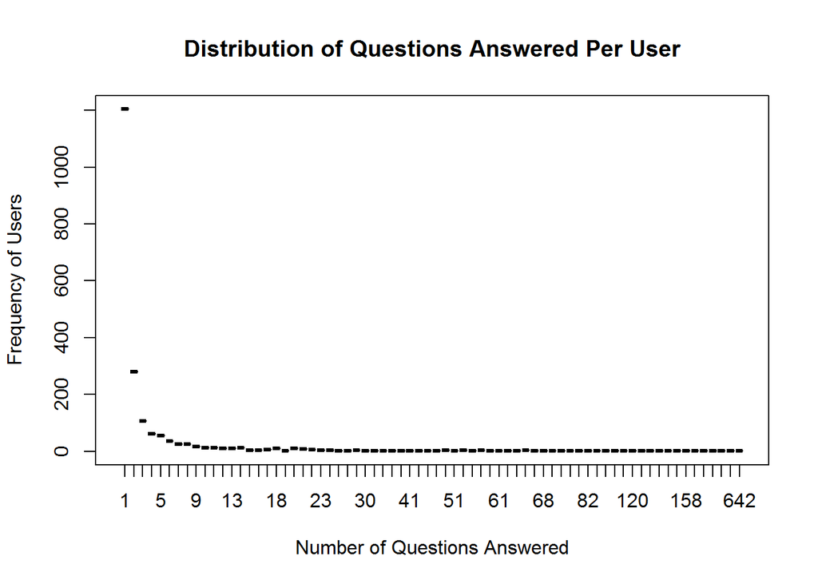

```r
rQAs_answers <- subset(rQAs, type == 'answer')
ans_freq <- as.data.frame(table(table(rQAs_answers$user)))
plot(ans_freq, main = "Distribution of Questions Answered Per User",
     xlab = "Number of Questions Answered",
     ylab = "Frequency of Users")
```

I followed the advice on post @1497 on Piazza to plot the distribution of questions answered per user, rather than looking at each individual user.

## 2. What are the most common tags?

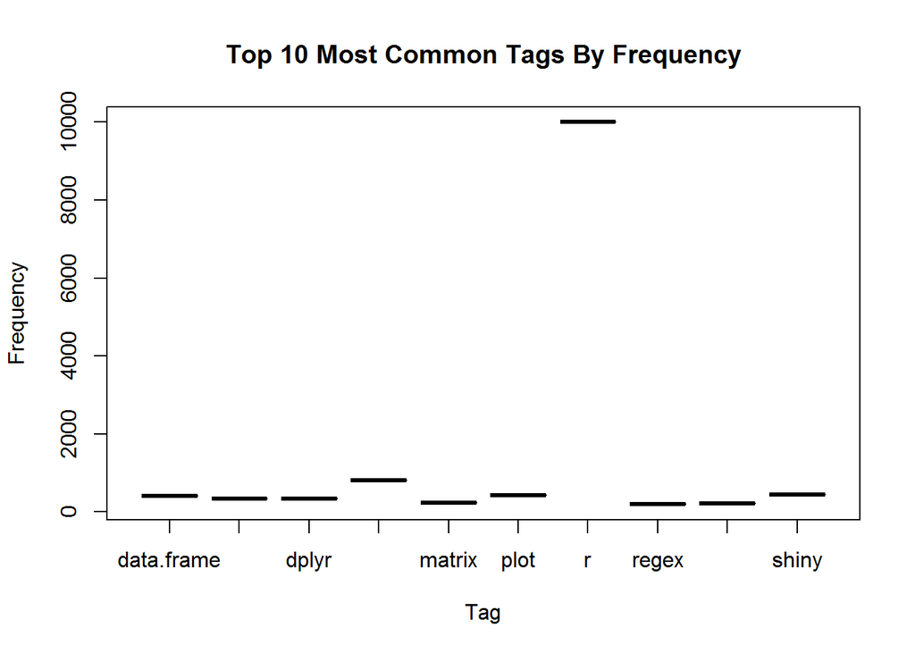

```r
R200pages <- readRDS("R200pages.rda")

# get the tags extracted in Part 1
tags <- as.character(R200pages$tags)

# Put them all in 1 big vector and get the top 10
top10tags <- sort(table(unlist(strsplit(tags, "; "))), decreasing = TRUE)[1:10]
top10tags <- data.frame(tag = names(top10tags),
                        freq = top10tags)
plot(top10tags, main = "Top 10 Most Common Tags By Frequency",
     xlab = "Tag", ylab = "Frequency")
```

I read in my data frame from Part 1, and then took their tags. From there, I got the individual tags and found the most common ones.

## 3. How many questions are about ggplot?

```r
rQAs_questions <- subset(rQAs, type == 'question')

# Since grepl returns logicals, sum them up
sum(grepl("ggplot", rQAs_questions$text, ignore.case = TRUE))
```

```
## [1] 959
```

I subsetted the given data to filter only the questions, and then used regex to find which questions contained ggplot within its text field. Since grepl() returns logicals, I used sum() to count them up.

## 4. How many questions involve XML, HTML, or Web Scraping?

```r
sum(grepl("(xml)|(html)|(web scraping)", rQAs$text, ignore.case = TRUE))
```

```
## [1] 5457
```

This was the same thing as the last problem, except that it asks for questions involving these, rather than about them, meaning that answers and comments should also be included.

## 5. What are the names of the R functions referenced in the titles of the posts?

```r
# rownames contain URLs, which will have the title of the post
rQAs_titles <- rownames(rQAs)

# Example URL is in this format
# "http://stackoverflow.com/questions/32566505/r-how-to-parallelize-multi-panel-plotting-with-lattice-in-r-3-2-1.title21"

# First, remove everything before the title
rQAs_titles_cleaned <- gsub(".+\\d+/", "", rQAs_titles)

# Then, remove everything after the title
rQAs_titles_cleaned <- gsub("\\..*", "", rQAs_titles_cleaned)

# Now, put it all in 1 big vector
rQAs_titles_words <- unlist(strsplit(rQAs_titles_cleaned, "-"))

checkFunction <- function(word) {
  if (!is.character(word))
    return(NULL)
  if (object.size(word) > 10000)
    return(NULL)
  if (is.function(get0(word)))
    return(word)
}

title_functions <- sapply(rQAs_titles_words, checkFunction)

# Remove NULL values
title_functions_cleaned <- title_functions[!sapply(title_functions, is.null)]

head(unique(title_functions_cleaned))
```

```
## [[1]]
## [1] "text"
##
## [[2]]
## [1] "numeric"
##
## [[3]]
## [1] "sum"
##
## [[4]]
## [1] "data"
##
## [[5]]
## [1] "order"
##
## [[6]]
## [1] "get"
```

For this problem, I took the rownames, which contained the URLs, and then extracted the titles from there using regex. Then, I wrote a function to see if the argument is a function. get0() combines get() and exists(). If it was a function, the name of the function is returned, otherwise NULL is returned. Then I removed the NULL values and used unique() to get a list of functions in the titles of the posts. I was going to use sort() and table() and then plot() the most common functions, but attempting to use table() kept making RStudio crash. Also, the error checking that my checkFunction() does was added in for the following question.

## 6. What are the names of the R functions referenced in the accepted answers and comments of the posts? We can do better than we did in processing the title of the posts as there is HTML markup and we can find content in code blocks.

```r
rQAs_ans_com <- subset(rQAs, type != "question")

checkText <- function(text) {
  html <- htmlParse(text)
  code <- getNodeSet(html, "//code")
  code <- sapply(code, trimXMLValue)
  code <- setMissingAsNA(code)
  sapply(code, checkFunction)
}

text_functions <- sapply(rQAs_ans_com$text, checkText)

# Remove NULL values
text_functions_cleaned <- text_functions[!sapply(text_functions, is.null)]

head(unique(text_functions_cleaned))
```

```
## [[1]]
## [1] "unlist"
##
## [[2]]
## [1] "str"
##
## [[3]]
## [1] "range"
##
## [[4]]
## [1] "Reduce"
##
## [[5]]
## [1] "strsplit"
##
## [[6]]
## [1] "combn"
```

I couldn’t do exactly what this question asked for, getting the accepted values because I think I got banned from Stack Overflow because I kept testing my function against pages for Part 2. But what I did instead was that I subsetted the answers and the comments from the given dataset, rQAs. From there I wrote another function to check the text field in my subsetted data for functions. My XPath here was to find the code blocks, and I extracted the values inside. I then called the function I created in the previous question, and followed similar steps.

```r
library(RCurl)
library(XML)
library(plyr)

setwd("C:/Users/Grant/Documents/UC Davis/STA 141/Assignment 6")

baseUrl <- "http://stackoverflow.com"
trimXMLValue <- function(x) xmlValue(x, trim = TRUE)
setMissingAsNA <- function(x) {
  if (length(x) == 0) ans <- NA
  else ans <- x[[1]]
}

rdoc <- getURLContent("http://stackoverflow.com/questions/tagged/r?sort=newest&pagesize=50")
rhtml <- htmlParse(rdoc, asText = TRUE)

# Scrapes a page of Stack Overflow with a given tag (ie. r),
# ex. http://stackoverflow.com/questions/tagged/r?sort=newest&pageSize=50
#
# Args:
#   page: the page to be scraped, once it has been htmlParsed
#
# Returns:
#   A dataframe containing the summary for the page,
#   which has:
#     id, date, tags, title, url
#     views, votes, answers, user, reputation
scrapePage <- function(page) {
  post <- getNodeSet(page, "//div[@class = 'question-summary']")

  scrapePost <- function(post) {
    getId <- function(post) {
      id <- getNodeSet(post, "./@id")
      id <- setMissingAsNA(id)
      id <- as.character(gsub("\\D", "", id))
    }

    getDate <- function(post) {
      date <- getNodeSet(post, ".//span[@class = 'relativetime']/@title")
      date <- as.character(unlist(sapply(date, "[[", 1)))
    }

    getTags <- function(post) {
      tags <- getNodeSet(post, ".//div[contains(@class, 'tags ')]")
      tags <- sapply(tags, trimXMLValue)
      tags <- setMissingAsNA(tags)
      tags <- as.character(gsub(" ", "; ", tags))
    }

    getTitle <- function(post) {
      title <- getNodeSet(post, ".//div[@class = 'summary']/h3/a")
      title <- sapply(title, trimXMLValue)
      title <- setMissingAsNA(title)
    }

    getUrl <- function(post) {
      url <- getNodeSet(post, ".//div[@class = 'summary']/h3/a/@href")
      url <- setMissingAsNA(url)
      if (!is.na(url)) url <- paste0(baseUrl, url)
    }

    getViews <- function(post) {
      views <- getNodeSet(post, ".//div[@class = 'views ']/@title")
      views <- gsub("\\D", "", views)
      views <- setMissingAsNA(views)
    }

    getVotes <- function(post) {
      votes <- getNodeSet(post, ".//span[@class = 'vote-count-post ']")
      votes <- sapply(votes, trimXMLValue)
      votes <- setMissingAsNA(votes)
    }

    getAnswers <- function(post) {
      answers <- getNodeSet(post, ".//div[contains(@class, 'status')]")
      answers <- sapply(answers, trimXMLValue)
      answers <- setMissingAsNA(answers)
      answers <- gsub("answers*", "", answers)
    }

    getUser <- function(post) {
      numChildren <- xpathSApply(post, ".//div[@class = 'user-details']", xmlChildren)
      if (length(numChildren) > 2)
        user <- getNodeSet(post, ".//div[@class = 'user-details']/a")
      else
        user <- getNodeSet(post, ".//div[@class = 'user-details']")
      user <- sapply(user, trimXMLValue)
      user <- setMissingAsNA(user)
    }

    getReputation <- function(post) {
      reputation <- getNodeSet(post, ".//span[@class = 'reputation-score']")
      reputation <- sapply(reputation, trimXMLValue)
      reputation <- setMissingAsNA(reputation)
    }

    summary <- data.frame(id = getId(post),
                          date = getDate(post),
                          tags = getTags(post),
                          title = getTitle(post),
                          url = getUrl(post),
                          views = getViews(post),
                          votes = getVotes(post),
                          answers = getAnswers(post),
                          user = getUser(post),
                          reputation = getReputation(post),
                          stringsAsFactors = FALSE)
  }
  result <- sapply(post, scrapePost)
  t(result)
}

page1 <- as.data.frame(scrapePage(rhtml))

# Scrapes summaries from pages on Stack Overflow
# pages are ordered from newest first, with pagesize 50
#
# Args:
#   forum: the forum/tag to be scraped from
#   numPages: the number of pages to scrape, with default Inf
#
# Returns:
#   A dataframe containing the summaries for numPages,
#   see Returns from "scrapePage" for specifics
scrapeStackOverflow <- function(forum, numPages = Inf) {
  doc <- getURLContent(paste0(baseUrl, "/questions/tagged/", forum, "?sort=newest&pagesize=50"))
  page <- htmlParse(doc, asText = TRUE)
  result <- data.frame()
  curPage <- 1
  while (curPage <= numPages) {
    result <- rbind(result, scrapePage(page))
    nextUrl <- as.character(getNodeSet(page, "//div/a[@rel = 'next']/@href"))
    if (length(nextUrl) == 0)
      break
    tempDoc <- rawToChar(getURLContent(paste0(baseUrl, nextUrl), binary = TRUE))
    page <- htmlParse(tempDoc, asText = TRUE)
    curPage <- curPage + 1
  }
  result
}

R2pages <- scrapeStackOverflow("r", 2)
R200pages <- scrapeStackOverflow("r", 200)
saveRDS(R200pages, file = 'R200pages.rda')

allPagesR <- scrapeStackOverflow("r")

# Part 2

indPostUrl <- getURLContent("http://stackoverflow.com/questions/1395528/scraping-html-tables-into-r-data-frames-using-the-xml-package")
indPost <- htmlParse(indPostUrl, asText = TRUE)

# Scrapes all entries (question, answers, comments)
# from an individual Stack Overflow post
#
# Args:
#   post: the post to be scraped, once it has been htmlParsed
#
# Returns:
#   A dataframe containing:
#     user, userid, date, reputation, score,
#     text, type, parent, id, qid
#   for every entry
scrapeEntries <- function(post) {
  question <- getNodeSet(post, "//div[@class = 'question']")
  comments <- getNodeSet(post, "//div[@class = 'comments ']")
  answers <- getNodeSet(post, "//div[@id = 'answers']")

  scrapeQuestion <- function(question) {
    getUser <- function(question) {
      numChildren <- xpathSApply(question, ".//div[@class = 'user-details']", xmlChildren)
      if (length(numChildren) > 2)
        user <- getNodeSet(question, ".//div[@class = 'user-details']/a")
      else
        user <- getNodeSet(question, ".//div[@class = 'user-details']")
      user <- sapply(user, trimXMLValue)
      user <- setMissingAsNA(user)
    }

    getUserid <- function(question) {
      userid <- getNodeSet(question, ".//div[@class = 'user-details']/a/@href")
      userid <- setMissingAsNA(userid)
      userid <- as.character(gsub("/(\\D*)/*", "", userid))
    }
```

```r
    getDate <- function(question) {
      date <- getNodeSet(question, ".//span[@class = 'relativetime']/@title")
      date <- as.character(unlist(sapply(date, "[[", 1)))
    }

    getReputation <- function(question) {
      reputation <- getNodeSet(question, ".//span[@class = 'reputation-score']")
      reputation <- sapply(reputation, trimXMLValue)
      reputation <- setMissingAsNA(reputation)
    }

    getScore <- function(question) {
      score <- getNodeSet(question, ".//span[@class = 'vote-count-post ']")
      score <- sapply(score, trimXMLValue)
      score <- setMissingAsNA(score)
    }

    getText <- function(question) {
      text <- getNodeSet(question, ".//div[@class = 'post-text']")
      text <- sapply(text, xmlValue)
      text <- setMissingAsNA(text)
    }

    getType <- function(question) {
      type <- "question"
    }

    getParent <- function(question) {
      parent <- NA
    }

    getId <- function(question) {
      id <- as.character(getNodeSet(question, "./@data-questionid"))
      id <- setMissingAsNA(id)
    }

    getQid <- function(question) {
      qid <- as.character(getNodeSet(question, "./@data-questionid"))
      qid <- setMissingAsNA(qid)
    }

    summary <- data.frame(user = getUser(question),
                          userid = getUserid(question),
                          date = getDate(question),
                          reputation = getReputation(question),
                          score = getScore(question),
                          text = getText(question),
                          type = getType(question),
                          parent = getParent(question),
                          id = getId(question),
                          qid = getQid(question),
                          stringsAsFactors = FALSE)
  }

  scrapeComments <- function(comments) {
    comment <- getNodeSet(comments, ".//tr[@class = 'comment ']")

    scrapeComment <- function(comment) {
      getUser <- function(comment) {
        user <- getNodeSet(comment, ".//a[contains(@class, 'comment-user')]")
        user <- sapply(user, trimXMLValue)
        user <- setMissingAsNA(user)
      }

      getUserid <- function(comment) {
        userid <- getNodeSet(comment, ".//a[contains(@class, 'comment-user')]/@href")
        userid <- setMissingAsNA(userid)
        userid <- as.character(gsub("/(\\D*)/*", "", userid))
      }

      getDate <- function(comment) {
        date <- getNodeSet(comment, ".//span[@class = 'relativetime-clean']/@title")
        date <- as.character(unlist(sapply(date, "[[", 1)))
      }

      getReputation <- function(comment) {
        reputation <- getNodeSet(comment, ".//a[contains(@class, 'comment-user')]/@title")
        reputation <- setMissingAsNA(reputation)
        reputation <- as.character(gsub("\\D", "", reputation))
      }

      getScore <- function(comment) {
        score <- getNodeSet(comment, ".//td[@class = ' comment-score']")
        score <- suppressWarnings(as.numeric(sapply(score, trimXMLValue)))
      }

      getText <- function(comment) {
        text <- getNodeSet(comment, ".//span[@class = 'comment-copy']")
        text <- sapply(text, trimXMLValue)
        text <- setMissingAsNA(text)
      }

      getType <- function(comment) {
        type <- "comment"
      }

      getParent <- function(comment) {
        parent <- getNodeSet(comment, "./../../../@id")
        parent <- setMissingAsNA(parent)
        parent <- as.character(gsub("\\D", "", parent))
      }

      getId <- function(comment) {
        id <- getNodeSet(comment, "./@id")
        id <- setMissingAsNA(id)
        id <- as.character(gsub("\\D", "", id))
      }

      getQid <- function(comment) {
        qid <- as.character(getNodeSet(comment, "//div[@class = 'question']/@data-questionid"))
        qid <- setMissingAsNA(qid)
      }

      summary <- data.frame(user = getUser(comment),
                            userid = getUserid(comment),
                            date = getDate(comment),
                            reputation = getReputation(comment),
                            score = getScore(comment),
                            text = getText(comment),
                            type = getType(comment),
                            parent = getParent(comment),
                            id = getId(comment),
                            qid = getQid(comment),
                            stringsAsFactors = FALSE)
    }

    sapply(comment, scrapeComment)
  }

  scrapeAnswers <- function(answers) {
    answer <- getNodeSet(answers, ".//div[@class = 'answer accepted-answer' or @class = 'answer']")

    scrapeAnswer <- function(answer) {
      getUser <- function(answer) {
        user <- getNodeSet(answer, ".//div[@class = 'user-details']")
        if (length(user) > 1) {
          user <- user[[length(user)]]
          user <- getNodeSet(user, "./a")
        }
        user <- sapply(user, trimXMLValue)
        user <- setMissingAsNA(user)
      }

      getUserid <- function(answer) {
        userid <- getNodeSet(answer, ".//div[@class = 'user-details']")
        if (length(userid) > 1) {
          userid <- userid[[length(userid)]]
          userid <- getNodeSet(userid, "./a/@href")
        }
        else userid <- NA
        userid <- as.character(gsub("/(\\D*)/*", "", userid))
      }

      getDate <- function(answer) {
        date <- getNodeSet(answer, ".//span[@class = 'relativetime']/@title")
        if (length(date) > 1)
          date <- date[[length(date)]]
        date <- as.character(unlist(sapply(date, "[[", 1)))
      }

      getReputation <- function(answer) {
        reputation <- getNodeSet(answer, ".//span[contains(@class, 'reputation-score')]/@title")
        reputation <- setMissingAsNA(reputation)
        reputation <- as.character(gsub("\\D", "", reputation))
      }

      getScore <- function(answer) {
        score <- getNodeSet(answer, ".//span[@class = 'vote-count-post ']")
        score <- suppressWarnings(as.numeric(sapply(score, trimXMLValue)))
      }
```

```r
      getText <- function(answer) {
        text <- getNodeSet(answer, ".//div[@class = 'post-text']")
        text <- sapply(text, trimXMLValue)
        text <- setMissingAsNA(text)
      }

      getType <- function(answer) {
        type <- "answer"
      }

      getParent <- function(answer) {
        parent <- NA
      }

      getId <- function(answer) {
        id <- getNodeSet(answer, "./@id")
        id <- setMissingAsNA(id)
        id <- as.character(gsub("\\D", "", id))
      }

      getQid <- function(answer) {
        qid <- as.character(getNodeSet(answer, "//div[@class = 'question']/@data-questionid"))
        qid <- setMissingAsNA(qid)
      }

      summary <- data.frame(user = getUser(answer),
                            userid = getUserid(answer),
                            date = getDate(answer),
                            reputation = getReputation(answer),
                            score = getScore(answer),
                            text = getText(answer),
                            type = getType(answer),
                            parent = getParent(answer),
                            id = getId(answer),
                            qid = getQid(answer),
                            stringsAsFactors = FALSE)
    }

    temp <- lapply(answer, scrapeAnswer)
    ldply(temp, data.frame)
  }

  questionDF <- t(data.frame(sapply(question, scrapeQuestion)))
  commentsDF <- t(data.frame(sapply(comments, scrapeComments)))
  answersDF <- data.frame(lapply(answers, scrapeAnswers))
  result <- rbind(questionDF, commentsDF, answersDF)
  rownames(result) <- NULL
  return(result)
}

scrapedPost <- data.frame(scrapeEntries(indPost))

post2 <- htmlParse(getURLContent("http://stackoverflow.com/questions/1727772/quickly-reading-very-large-tables-as-dataframes-in-r"), asText = TRUE)
scrapedPost2 <- scrapeEntries(post2)

# Part 3
load("rQAs.rda")

# 1
rQAs_answers <- subset(rQAs, type == 'answer')
ans_freq <- as.data.frame(table(table(rQAs_answers$user)))
plot(ans_freq, main = "Distribution of Questions Answered Per User",
     xlab = "Number of Questions Answered",
     ylab = "Frequency of Users")

# 2
R200pages <- readRDS("R200pages.rda")

# get the tags extracted in Part 1
tags <- as.character(R200pages$tags)

# Put them all in 1 big vector and get the top 10
top10tags <- sort(table(unlist(strsplit(tags, "; "))), decreasing = TRUE)[1:10]
top10tags <- data.frame(tag = names(top10tags),
                        freq = top10tags)
plot(top10tags, main = "Top 10 Most Common Tags By Frequency",
     xlab = "Tag", ylab = "Frequency")

# 3
rQAs_questions <- subset(rQAs, type == 'question')

# Since grepl returns logicals, sum them up
sum(grepl("ggplot", rQAs_questions$text, ignore.case = TRUE))

# 4
sum(grepl("(xml)|(html)|(web scraping)", rQAs$text, ignore.case = TRUE))

# 5
# rownames contain URLs, which will have the title of the post
rQAs_titles <- rownames(rQAs)

# Example URL is in this format
# "http://stackoverflow.com/questions/32566505/r-how-to-parallelize-multi-panel-plotting-with-lattice-in-r-3-2-1.title21"

# First, remove everything before the title
rQAs_titles_cleaned <- gsub(".+\\d+/", "", rQAs_titles)

# Then, remove everything after the title
rQAs_titles_cleaned <- gsub("\\..*", "", rQAs_titles_cleaned)

# Now, put it all in 1 big vector
rQAs_titles_words <- unlist(strsplit(rQAs_titles_cleaned, "-"))

checkFunction <- function(word) {
  # Checks word to see if it's a function
  #
  # Args:
  #   word: the word to determine if it's a function
  #
  # Returns:
  #   Either name of the function or NULL
  if (!is.character(word))
    return(NULL)
  if (object.size(word) > 10000)
    return(NULL)
  if (is.function(get0(word)))
    return(word)
}

title_functions <- sapply(rQAs_titles_words, checkFunction)

# Remove NULL values
title_functions_cleaned <- title_functions[!sapply(title_functions, is.null)]

unique(title_functions_cleaned)

# 6
rQAs_ans_com <- subset(rQAs, type != "question")

checkText <- function(text) {
  # Checks text to see if there are functions in it
  #
  # Args:
  #   text: the text to be checked for functions
  #
  # Returns:
  #   Either names of functions or NULL
  html <- htmlParse(text)
  code <- getNodeSet(html, "//code")
  code <- sapply(code, trimXMLValue)
  code <- setMissingAsNA(code)
  sapply(code, checkFunction)
}

text_functions <- sapply(rQAs_ans_com$text, checkText)

# Remove NULL values
text_functions_cleaned <- text_functions[!sapply(text_functions, is.null)]

unique(text_functions_cleaned)
```